# 🎧 Mi vida en canciones

## 🗺️ Mis eras musicales

¿Mi gusto cambió de golpe o de a poco? Para responderlo puse **todos mis meses en fila**, cada uno descrito por la mezcla de géneros que escuché, y le pedí a un algoritmo que cortara la fila en tramos donde los meses se parecen entre sí. Cada tramo es una **era**: una etapa con un sonido propio, con inicio y final. El algoritmo decidió solo cuántas eras hay.

El algoritmo encontró **5 eras**.

**Mis eras**

Era 1

Estilo: Doom metal

Artista emblema: Saint Vitus

oct 2013 → ene 2015 · 16 meses

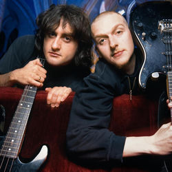

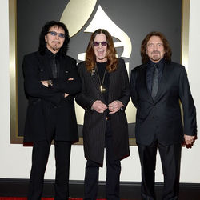

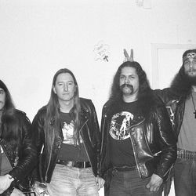

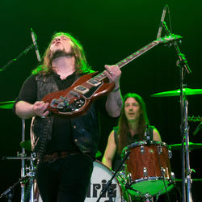

Godflesh · Black Sabbath · Saint Vitus · Electric Wizard

Doom metal

13%

Heavy metal

11%

Death metal

10%

Era 2

Estilo: Heavy metal

Artista emblema: Black Sabbath

feb 2015 → abr 2018 · 34 meses

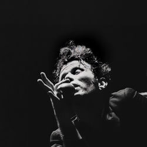

Tom Waits · Amenra · Tenemos Explosivos · Charly García

Heavy metal

11%

Post-punk

6%

Thrash metal

6%

Era 3

Estilo: Post-punk

Artista emblema: IDLES

may 2018 → abr 2022 · 43 meses

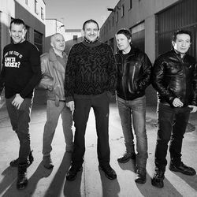

IDLES · Interpol · Nick Cave & the Bad Seeds · La Polla Records

Post-punk

17%

Heavy metal

5%

Hip-hop

4%

Era 4

Estilo: Post-punk

Artista emblema: Black Country, New Road

may 2022 → feb 2024 · 22 meses

Tenemos Explosivos · Black Country, New Road · IDLES · Deafheaven

Post-punk

21%

Post-hardcore

9%

Hip-hop

5%

Era 5

Estilo: Post-punk

Artista emblema: Fontaines D.C.

mar 2024 → oct 2026 · 30 meses

Fontaines D.C. · La Brigida Orquesta · Tenemos Explosivos · Black Country, New Road

Post-punk

17%

Black metal

7%

Post-hardcore

4%

**¿Por qué son eras?**

Cada barra es una era y muestra **de qué estuvo hecha**: qué parte de lo que escuché en esos meses fue de cada género. Si las barras se ven distintas entre sí, el algoritmo hizo bien su trabajo.

De qué estuvo hecha cada era

Proporción de mis 6 géneros principales en cada era (el resto, en gris)

[interactive chart not shown]

**¿Qué me dice?** Las dos primeras eras son de **metal clásico**: doom, death, stoner y heavy metal (Saint Vitus, Godflesh, Black Sabbath, Electric Wizard), con Tom Waits y Amenra de compañía en la segunda. Desde mayo de 2018 el **post-punk** toma el control y no lo suelta, pero cambia de compañía: primero con heavy metal, hip-hop y sludge (IDLES, Interpol, Nick Cave), después con post-hardcore y black metal (Black Country, New Road, Deafheaven y la vuelta fuerte de Tenemos Explosivos) y ahora con la nueva escena chilena (La Brígida Orquesta) y un black metal experimental: Deafheaven, que lo mezcla con shoegaze, Agriculture y Mamaleek suman casi nueve de cada diez escuchas de black metal de esta era. Mi gusto no reemplazó una cosa por otra: **fue sumando capas**.

**Detalle técnico**

**Método.** *Clustering* jerárquico aglomerativo **con restricción de contigüidad** y criterio de **Ward** (Grimm, 1987), el mismo que usan geólogos y paleoecólogos para dividir capas de sedimento en zonas. Cada mes (con al menos 300 escuchas) es un vector con la proporción de los 15 géneros principales. Se parte con cada mes como grupo y en cada paso se fusionan los **dos grupos vecinos** cuya unión aumenta menos la varianza interna. A diferencia de k-means, nunca junta meses separados en el tiempo, así que cada era es un tramo continuo. El número de eras se elige donde el costo de seguir fusionando da el mayor salto (entre 4 y 8 eras).

Costo de fusionar eras

Cuánta heterogeneidad se agrega al pasar de n a n-1 eras. En verde, el número elegido (5)

[interactive chart not shown]

## 🧪 Laboratorio de clasificación

Cuatro técnicas de estadística y aprendizaje automático para mirar mis gustos desde otros ángulos. Cada una trae su teoría y lo que me dice.

**🧭 El espacio de mis gustos**

**Teoría.** Pierre Bourdieu, en *La distinción* (1979), usó el **análisis de correspondencias** para dibujar el “espacio de los gustos” de la sociedad francesa: un mapa donde los gustos que suelen ir juntos quedan cerca. Aquí uso la misma técnica con mis propios datos: géneros (en morado) y años (en verde) en un mismo plano. Un año queda cerca de los géneros que escuché **más de lo normal** ese año, y los años van cambiando de color de claro a oscuro.

El espacio de mis gustos

Análisis de correspondencias de géneros (morado) y años (verde, de claro a oscuro). Los dos ejes resumen el 78% de las diferencias

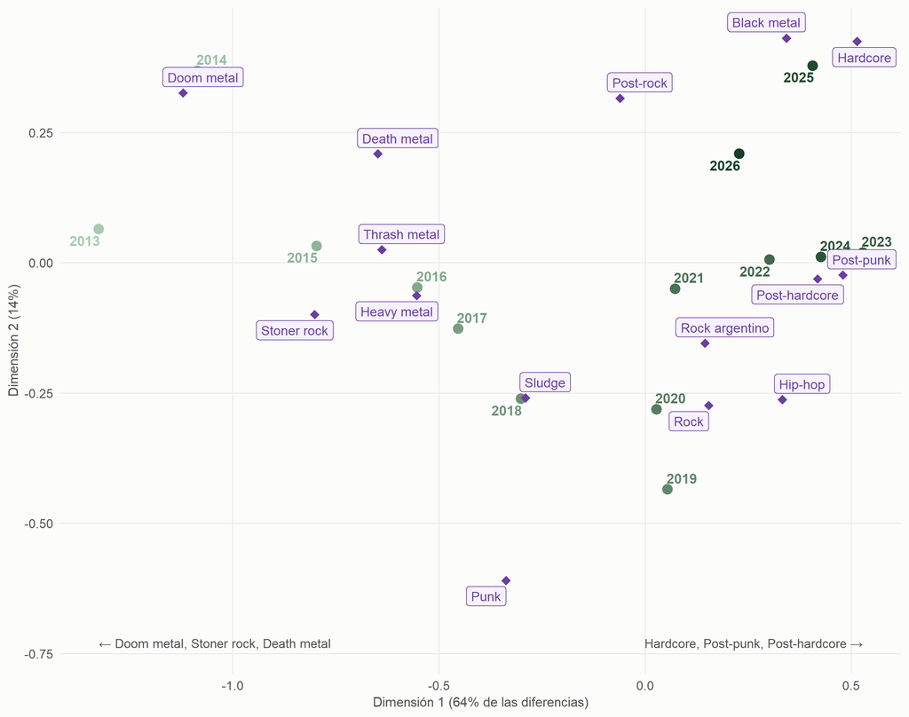

**¿Qué me dice?** La primera dimensión explica 64% de las diferencias entre años, y es básicamente **el paso del tiempo**: a la izquierda quedan los géneros de mis primeros años (Doom metal, Stoner rock, Death metal) y a la derecha los de ahora (Hardcore, Post-punk, Post-hardcore). Los años avanzan casi en línea recta de un extremo al otro: mi gusto no saltó de golpe, **se desplazó de forma gradual**, año a año. La segunda dimensión separa lo más extremo y atmosférico (arriba) del rock y el punk más clásicos (abajo), y muestra que en los últimos años volví a subir hacia lo intenso, ahora desde el post-punk y el post-hardcore.

**🎧 Playlists ocultas**

**Teoría.** El **modelo de tópicos LDA** (*Latent Dirichlet Allocation*, Blei, Ng y Jordan, 2003) se creó para descubrir temas en colecciones de textos: supone que cada documento mezcla varios temas y que cada tema es un conjunto de palabras que aparecen juntas. Aquí cada **semana** es un “documento” y cada **artista**, una “palabra”. Los “temas” que encuentra son mis **playlists ocultas**: artistas que tiendo a escuchar en las mismas semanas, aunque nunca haya armado esas listas.

Mis playlists ocultas a lo largo de los años

Peso de cada playlist en las semanas de cada año. Cada una se nombra por su año más fuerte y su artista principal

[interactive chart not shown]

Qué hay en cada playlist oculta

Los 6 artistas más característicos de cada una

↕ Haz clic en el nombre de una columna para ordenar

| Playlist | Artistas más característicos |
| --- | --- |
| La de 2014: Godflesh | Godflesh, Yajaira, Electric Wizard, Pearl Jam, Paradise Lost, Nuclear |
| La de 2017: Tom Waits | Tom Waits, Neurosis, Napalm Death, Judas Priest, Type O Negative, Mark Lanegan |
| La de 2019: Amenra | Amenra, Nick Cave & the Bad Seeds, Interpol, The Smashing Pumpkins, La Polla Records, Fugazi |
| La de 2022: Tenemos Explosivos | Tenemos Explosivos, IDLES, Deafheaven, Sumo, Fiskales Ad-Hok, Interpol |
| La de 2023: Black Country | Black Country, New Road, Los Tres, The Smiths, Tenemos Explosivos, Asamblea Internacional del Fuego, Deafheaven |
| La de 2026: Fontaines D.C. | Fontaines D.C., La Brigida Orquesta, Candelabro, Marcel Duchamp, Deafheaven, Agriculture |

**¿Qué me dice?** El modelo no sabe nada de géneros ni de fechas: solo ve qué artistas comparten semana. Aun así, cada playlist oculta corresponde a **una etapa de mi vida**: aparece, domina un par de años y se apaga, dejando paso a la siguiente. Eso confirma con otra técnica lo que mostraron las eras. Lo interesante son las mezclas que arma solo, juntando artistas de géneros muy distintos que en mi cabeza van juntos porque los escuché en la misma época, como Tom Waits con Neurosis y Napalm Death, o IDLES con Sumo y Fiskales Ad-Hok.

**⏳ ¿Cuánto dura un amor musical?**

**Teoría.** El **análisis de supervivencia** se creó en medicina para estimar cuánto tiempo pasa hasta un evento, como una recaída. El estimador de **Kaplan-Meier** (1958) permite usar casos que todavía no tienen el evento (*censurados*). Aquí el “paciente” es cada artista que escuché al menos 20 veces; su vida empieza el día que lo escuché por primera vez, y “muere” si llevo más de un año sin ponerlo. Los que sigo escuchando están vivos (censurados).

¿Cuánto sobrevive un artista en mi vida?

Probabilidad de que un artista (con al menos 20 escuchas) siga sonando X años después de descubrirlo

[interactive chart not shown]

**¿Qué me dice?** De 600 artistas que escuché al menos 20 veces, 267 ya los “abandoné”. La **vida media** de un amor musical, el momento en que la mitad de los artistas ya dejó de sonar, es de unos **10.6 años**: cuando un artista entra a mi vida, tiende a quedarse mucho tiempo. La comparación entre artistas chilenos y extranjeros tiene un valor p de 0,005 (prueba log-rank): la diferencia es estadísticamente significativa.

**🤖 ¿Puede una máquina adivinar cuándo escucho?**

**Teoría.** Le pido a varias técnicas de clasificación que adivinen **en qué momento** escuché cada canción (horario laboral, noche o fin de semana) sabiendo solo cómo es la música: ánimo, género, popularidad del artista y año. Cada una aprende con una parte de los datos y se evalúa con otra que no vio: aquí, con **artistas que nunca vio**, para que no pueda hacer trampa memorizándolos. Pruebo cinco: una **línea base** que siempre adivina el momento más común; una **regresión logística multinomial**, que mide cuánto empuja cada característica hacia cada momento; un **árbol de inferencia condicional** (Hothorn, Hornik y Zeileis, 2006), que aprende reglas legibles y solo corta cuando la diferencia es estadísticamente significativa; un **random forest** (Breiman, 2001), que combina cientos de árboles independientes, y un **gradient boosting** (Friedman, 2001; Chen y Guestrin, 2016), que suma árboles chicos donde cada uno corrige los errores de los anteriores: estos dos últimos suelen ser los que más aciertan, pero no se pueden leer. Aquí muestro solo la que mejor adivina; la comparación completa está en la metodología.

¿En qué se fija el random forest?

Importancia por permutación: cuánto empeora si se desordena cada característica

[interactive chart not shown]

**¿Qué me dice?** Probé cinco técnicas (comparación en la metodología) y la que mejor adivina es el **random forest (300 árboles)**: acierta el 50% de las veces (38% balanceado, F1 de 37%), contra un 49% de la línea base (33% balanceado). Es decir, **casi no se puede adivinar**: la música que escucho es muy parecida a cualquier hora y en cualquier día. No tengo una “música de oficina” y otra de fin de semana: mi gusto me acompaña igual en todos lados. La característica en la que más se fija es **año**.

## 📝 Lo que dicen mis canciones

Bajé las letras de mis canciones más escuchadas desde [LRCLIB](https://lrclib.net), una base abierta de letras, para ver **de qué hablan**. Por derechos de autor aquí solo muestro palabras y temas agregados, nunca letras completas.

Por ahora tengo **6.980 letras** de las 8.000 canciones revisadas, que suman el **69%** de todas mis escuchas. Cada mes se suman las letras de las canciones nuevas.

**🌎 ¿En qué idioma?**

¿Canto en español o en inglés?

Idioma de las canciones escuchadas cada año (solo canciones con letra descargada)

[interactive chart not shown]

**¿Qué me dice?** En total, el 32% de lo que escucho (entre las canciones con letra) está en **español**. La evolución sigue a las eras: en 2014, en plena era del metal, el español era apenas un 6%; desde entonces fue subiendo hasta rondar entre el 35% y el 40% en los últimos años, de la mano de la escena chilena y argentina.

**🔤 Palabras más cantadas**

En español

Veces que escuché cada palabra (aparición en la letra × veces que escuché la canción)

[interactive chart not shown]

En inglés

Veces que escuché cada palabra (aparición en la letra × veces que escuché la canción)

[interactive chart not shown]

**🧩 Los temas de mis canciones**

**Teoría.** Es el mismo **modelo de tópicos LDA** de las playlists ocultas, ahora en su uso original: textos. Cada **letra** es un documento y el modelo encuentra grupos de palabras que suelen aparecer juntas en una misma canción. Cada grupo es un **tema**. Una canción puede mezclar varios temas, y el peso de un tema en mi vida depende de cuántas veces escuché las canciones que hablan de él.

Los temas de las canciones que escucho

Peso de cada tema en mis escuchas, de qué trata, sus palabras clave y la canción que mejor lo representa

El amor y la vida, en rock chileno y argentino 16%

Amor, vida, mundo y corazón, con el voseo rioplatense: el lado romántico del rock en castellano.

quiero, amor, vida, vos, corazón, mundo, vas, noche

🎵 Tenemos Explosivos — La libertad absoluta y el terror

Amor y despedidas 13%

Amar, sentir, quedarse o irse: canciones de pareja, de las que empiezan y de las que terminan.

love, feel, heart, baby, hear, head, stay, hold

🎵 IDLES — Samaritans

La vida y el paso del tiempo 12%

Reflexiones sobre la vida, la pérdida, los días que pasan y las ganas de cambiar.

time, life, day, mind, god, live, people, left

🎵 Fontaines D.C. — In ár gCroíthe go deo

Luz y oscuridad 12%

Día y noche, luz y sombra, cielo y sol: un imaginario contemplativo y melancólico.

eyes, night, light, black, sun, lost, kill, sky

🎵 Type O Negative — Black No. 1 (Little Miss Scare-All)

Deseo y noche, urbano y tropical 12%

Ganas, noche, fiesta y coqueteo: el lenguaje del trap, el reggaetón y la cumbia.

quiero, mami, gusta, quieres, dime, noche, calle, baby

🎵 La Brigida Orquesta — No Hay Apuro

Muerte, sangre y lo sagrado 12%

Sangre, muerte, almas y dioses: el imaginario del metal extremo.

die, death, blood, soul, dead, burn, fear, lies

🎵 Morbid Angel — Maze of Torment

Noches, peleas y quiebres 12%

Una noche, una chica, un corte, una pelea: la tensión y el quiebre del post-punk.

girl, coming, dance, hands, cut, house, sound, city

🎵 IDLES — Never Fight a Man with a Perm

Rabia, calle y dinero 11%

Enojo, violencia, plata y calle: el lado del hardcore y el hip-hop.

shit, fuck, money, nigga, boy, bring, rock, bitch

🎵 Nas — N.Y. State of Mind

De qué hablan mis canciones, año a año

Peso de cada tema en las escuchas de cada año

[interactive chart not shown]

**¿Qué me dice?** *Escrito el 24-10-2026, con 6.980 letras.* Los ocho temas quedan casi parejos (entre 11% y 16% cada uno): ninguno domina. El más presente es **el amor y la vida en español**, con el voseo del rock chileno y argentino (*quiero, amor, vida, vos, corazón*) y Tenemos Explosivos como ejemplo. A su lado aparece otra forma de hablar de amor en castellano, más de **deseo y noche**, la del lenguaje urbano y tropical (*mami, gusta, dime, noche, calle*), con La Brígida Orquesta. En inglés, el amor queda en **el amor y las despedidas** (*love, feel, heart, baby, stay, hold*), con IDLES. Le siguen **la vida y el paso del tiempo** (*time, life, day, mind, people*), con Fontaines D.C., y un imaginario contemplativo de **luz y oscuridad** (*eyes, night, light, black, sky*), con Type O Negative. Con más letras aparece un tema nuevo, el de **noches, peleas y quiebres** del post-punk (*girl, dance, hands, cut, city*), otra vez con IDLES. El lado más duro está en **la muerte, la sangre y lo sagrado** del metal (*die, death, blood, soul*), con Morbid Angel, y en **la rabia, la calle y el dinero** del hip-hop y el hardcore (*fuck, money, bring*). Los temas se separan primero por idioma, porque las palabras de cada idioma casi nunca se mezclan en una misma canción, y luego por escena: cada género tiene su propio vocabulario, y por eso un mismo gran tema, como el amor, aparece partido en varios.

## 🧠 Lectura psicológica

**NotaLo que dice la investigación sobre gustos como los míos**

*Escrito el 24-10-2026. Es una lectura lúdica: los estudios hablan de tendencias promedio en muchas personas, no de diagnósticos individuales.*

**Apertura, no rabia.** Con 70% de música *intensa*, mi perfil es casi puro “intenso y rebelde”. Rentfrow y Gosling (2003) encontraron que quienes prefieren rock, alternativo y metal puntúan más alto en **apertura a la experiencia** (curiosidad, gusto por ideas nuevas), y que esa preferencia **no** se asocia a más neuroticismo ni a menos amabilidad, contra el estereotipo. North (2008) encontró que los fans del metal se parecen mucho a los de la música clásica: creativos, tranquilos consigo mismos y algo introvertidos.

**La oscuridad como refugio.** Todos mis años caen en el cuadrante *tenso/oscuro*: valencia negativa y energía alta. La investigación sobre la “paradoja de la música triste” (Vuoskoski y otros, 2012) muestra que quienes disfrutan la música triste o sombría tienden a puntuar más alto en **empatía** y apertura. Y en música extrema, Sharman y Dingle (2015) vieron que escucharla después de enojarse no aumenta la rabia: ayuda a procesarla y sube las emociones positivas. Mis días más oscuros (doom de Cathedral, Black Sabbath y Witchfinder General) fueron todos entre 2013 y 2017; los más luminosos, de cumbia con **Chico Trujillo** y **La Floripondio**.

**Bajando las revoluciones.** La energía de lo que escucho cayó de 0,71 en 2013 a 0,41 en 2026, y la valencia subió de −0,43 a cerca de −0,25. Las eras lo muestran: empecé con el doom de Saint Vitus y Godflesh (2013–2014), seguí con el heavy metal de Black Sabbath, mezclado con Tom Waits y Amenra (2015–2018) y desde mediados de 2018 encadeno tres eras de post-punk: la de IDLES, la de Black Country, New Road y la actual de Fontaines D.C. Sigo en lo intenso, pero más melódico y menos extremo.

**La música como compañía de la rutina.** Escucho en horario de oficina y durante la pandemia escuché **un tercio menos** (21 escuchas al día, contra 32 antes): la música va pegada a la rutina, a trabajar y moverme, más que al tiempo libre. Después de la pandemia volví con todo, a 56 escuchas al día, y con el **doble de música chilena** (de 16% a 32%).

**Raíces que no se mueven.** En 14 años cambiaron los géneros, pero Tenemos Explosivos estuvo todos los años, y la escena local fue ganando espacio. Hoy exploro poco (7% de artistas nuevos): datos de plataformas como Deezer sugieren que, en promedio, la gente deja de buscar música nueva alrededor de los 30 años y vuelve a lo que la marcó.

## 🔁 Obsesiones y amores olvidados

**En loop**

**Teoría.** El **efecto de mera exposición** (Zajonc, 1968) dice que algo nos gusta más mientras más lo vemos o escuchamos. Pero Berlyne (1971) mostró que la relación es una **U invertida**: el gusto sube con la repetición hasta un punto y después cae por saturación. Las canciones en loop son ese peak; los “amores olvidados”, quizás, la bajada.

Canciones en loop

Las veces que más escuché una misma canción en un solo día

↕ Haz clic en el nombre de una columna para ordenar

| Día | Artista | Canción | Veces |
| --- | --- | --- | --- |
| 04-10-2019 | Wos | OKUPA | 20 |
| 30-01-2026 | KATTEYES | Alo | 19 |
| 21-02-2025 | Fontaines D.C. | It's Amazing to Be Young | 18 |
| 28-11-2025 | Macha y el Bloque Depresivo | Turista | 17 |
| 07-11-2024 | La Brigida Orquesta | Mejor Olvidar Ciertas Cosas | 12 |
| 20-02-2025 | Grupo Frontera | un x100to | 12 |
| 28-02-2024 | Las Ligas Menores | Accidente | 11 |
| 13-02-2023 | Tenemos Explosivos | Tártaro | 10 |
| 05-09-2023 | Nick Cave & the Bad Seeds | Skeleton Tree | 10 |
| 03-01-2024 | Asamblea Internacional del Fuego | Una Mujer En Medio De La Tormenta | 10 |

**Amores olvidados**

Amores olvidados

Artistas que escuché mucho y que llevo más de dos años sin poner

↕ Haz clic en el nombre de una columna para ordenar

| Artista | Escuchas | Su mejor año | Última vez |
| --- | --- | --- | --- |
| Bomba Estéreo | 635 | 2019 | 12-05-2023 |
| Discharge | 589 | 2014 | 12-09-2023 |
| Wos | 570 | 2019 | 13-08-2024 |
| Pentagram | 559 | 2014 | 11-09-2023 |
| Attaque 77 | 507 | 2015 | 27-01-2023 |
| In Solitude | 445 | 2014 | 18-08-2024 |
| La Bestia de Gevaudan | 372 | 2017 | 13-05-2024 |
| Doom | 327 | 2015 | 27-04-2023 |
| Protomartyr | 198 | 2023 | 13-02-2024 |
| Autopsy | 196 | 2014 | 13-10-2021 |

[output cut: 2 more lines]

**Los de siempre**

Los de siempre

Artistas presentes en más años distintos (con al menos 200 escuchas)

↕ Haz clic en el nombre de una columna para ordenar

| Artista | Escuchas | Años con escuchas | Desde |
| --- | --- | --- | --- |
| Tenemos Explosivos | 6453 | 14 | 2013 |
| Deafheaven | 3809 | 14 | 2013 |
| Black Sabbath | 2017 | 14 | 2013 |
| Fiskales Ad-Hok | 1793 | 14 | 2013 |
| Yajaira | 1792 | 14 | 2013 |
| Neurosis | 1790 | 14 | 2013 |
| Converge | 1354 | 14 | 2013 |
| Judas Priest | 1305 | 14 | 2013 |
| Jesu | 1239 | 14 | 2013 |
| Slayer | 1028 | 14 | 2013 |

## 🏁 Hitos

Escuchas que marcaron hitos

↕ Haz clic en el nombre de una columna para ordenar

| Escucha n.º | Día | Canción | Artista |
| --- | --- | --- | --- |
| 1 | 17-09-2013 | She Rides | Danzig |
| 1000 | 02-11-2013 | Desde El Umbral | Poema Arcanus |
| 10000 | 03-10-2014 | Sterile Prophet | Godflesh |
| 50000 | 01-07-2018 | Porcelina of the Vast Oceans | The Smashing Pumpkins |
| 100000 | 27-09-2022 | Slow Hands | Interpol |
| 150000 | 17-11-2024 | Las Simples Cosas | Macha y el Bloque Depresivo |

## 🗂️ Explorador de artistas

Todos los artistas con al menos 20 escuchas. Se puede buscar y ordenar por cualquier columna.

↕ Haz clic en el nombre de una columna para ordenar

| Artista | Escuchas | Canciones | Primera vez | Última vez | Género |
| --- | --- | --- | --- | --- | --- |
| Tenemos Explosivos | 6453 | 59 | 2013-11-09 | 2026-10-09 | Post-hardcore |
| IDLES | 4024 | 130 | 2019-11-28 | 2026-01-06 | Post-punk |
| Black Country, New Road | 3903 | 42 | 2021-12-27 | 2026-10-23 | Post-punk |
| Deafheaven | 3809 | 66 | 2013-12-20 | 2026-10-15 | Black metal |
| Fontaines D.C. | 3305 | 75 | 2020-08-21 | 2026-10-23 | Post-punk |
| Interpol | 3268 | 140 | 2017-09-02 | 2026-10-14 | Post-punk |
| Amenra | 2718 | 90 | 2015-01-28 | 2026-05-29 | Sludge |
| La Brigida Orquesta | 2474 | 48 | 2020-12-14 | 2026-10-15 | Jazz rap |
| The Smiths | 2471 | 159 | 2014-11-02 | 2026-03-28 | Post-punk |
| Charly García | 2228 | 202 | 2014-12-08 | 2026-03-27 | Rock argentino |

[output cut: 590 more lines]